The Tidyomics Blog

# The new tidy sccomp interface

Stefano Mangiola

2025-09-11

[figure not shown]

[figure not shown]

We announce the new tidy and modular interface for a `sccomp`, which improves modularity, and clarity. The main change is the modularisation of `sccomp` in functions which can be linked with the pipe operator `|>`.

| Function | Description |
| --- | --- |
| Estimation: `sccomp_stimate()` | which is usually run once in the analysis (per model). |
| Testing: `sccomp_test()` | which candy run multiple times, depending on how many contrasts you want to test (e.g. age, untreated vs treated). |
| Outlier removal: `sccomp_remove_outliers()` | which is usually run once after `sccomp_estimate()` in case you want to produce estimates not influenced by outlier data points. |
| Unwanted variation removal: `sccomp_remove_unwanted_variation()` | which is run after `sccomp_estimate()` and produces a dataset that just preserve the variability of your factor of interest. |
| Data replication: `sccomp_replicate()` | which is run after `sccomp_estimate()` and produces a dataset representing the theoretical data distribution according to the model (from the posterior distribution). |
| Plotting: `plot()` | which is run after `sccomp_test` and outputs a series of summary plots. |

# A reminder: what is `sccomp`

`sccomp`[^1] is a statistical model developed for differential variability analysis in compositional data, primarily used in cellular omics fields like single-cell genomics, proteomics, and microbiomics (Mangiola et al. 2023). It addresses limitations of existing methods in differential abundance analysis by incorporating several advanced features. `sccomp` effectively models compositional count data properties, which were previously not adequately addressed, and tackles cell-group-specific differential variability. This model uses a constrained Beta-binomial distribution to enable more precise analyses. Key capabilities of `sccomp` include improved differential abundance analyses through cross-sample information borrowing, outlier identification and exclusion, realistic data simulation, and facilitating cross-study knowledge transfer. By incorporating these features, `sccomp` provides a more comprehensive and accurate framework for analyzing cellular omics data, identifying crucial biological drivers such as disease progression markers in cancer and pathogen infection.

# Installation

**Bioconductor**

```r
if (!requireNamespace("BiocManager")) install.packages("BiocManager")
BiocManager::install("sccomp")
```

**Github**

```r
devtools::install_github("stemangiola/sccomp")
```

# Deprecation of the function `sccomp_glm()`

The new framework

```r
outlier_free_estimate =
  seurat_obj |>

  # Estimate
  sccomp_estimate(
    formula_composition = ~ type + continuous_covariate,
    sample = "sample",
    cell_group = "cell_group",
    cores = 1,
    verbose = FALSE
  ) |>
  # sccomp_estimate(
  #   formula_composition = ~ type + continuous_covariate,
  #   .sample =  sample,
  #   .cell_group = cell_group
  # ) |>

  # Remove outliers
  sccomp_remove_outliers()
```

[output not shown]

[output not shown]

[output cut: 148 more lines]

[output not shown]

[output not shown]

[output cut: 146 more lines]

[output not shown]

```r
# Test
outlier_free_estimate |>
  sccomp_test(contrasts = "typehealthy")
```

```
## sccomp model
## ============
##
## Model specifications:
##   Family: multi_beta_binomial
##   Composition formula: ~type + continuous_covariate
##   Variability formula: ~1
##   Inference method: pathfinder
##
## Data: Samples: 20   Cell groups: 30
##
## Column prefixes: c_ -> composition parameters  v_ -> variability parameters
##
## Convergence diagnostics:
##   For each parameter, n_eff is the effective sample size and R_k_hat is the potential
##   scale reduction factor on split chains (at convergence, R_k_hat = 1).
##
## # A tibble: 30 × 11
##    cell_group      parameter factor c_lower c_effect c_upper c_pH0  c_FDR c_rhat
##    <chr>           <chr>     <chr>    <dbl>    <dbl>   <dbl> <dbl>  <dbl>  <dbl>
##  1 B immature      typeheal… type     1.19     1.48    1.79  0     0        1.00
##  2 B mem           typeheal… type     1.24     1.56    1.90  0     0        1.00
##  3 CD4 cm S100A4   typeheal… type     0.912    1.13    1.37  0     0        1.00
##  4 CD4 cm high cy… typeheal… type    -2.45    -2.08   -1.69  0     0        1.01
##  5 CD4 cm ribosome typeheal… type    -1.67    -1.29   -0.901 0     0        1.00
##  6 CD4 em high cy… typeheal… type    -1.75    -1.41   -1.10  0     0        1.00
##  7 CD4 naive       typeheal… type     0.330    0.623   0.908 0     0        1.01
##  8 CD4 ribosome    typeheal… type     1.83     2.07    2.33  0     0        1.00
##  9 CD8 em 1        typeheal… type    -0.104    0.186   0.489 0.277 0.0389   1.00
## 10 CD8 em 2        typeheal… type    -1.52    -1.21   -0.894 0     0        1.00
## # ℹ 20 more rows
## # ℹ 2 more variables: c_ess_bulk <dbl>, c_ess_tail <dbl>
```

Replaces the old framework (that now will receive a deprecation warning)

```r
  seurat_obj |>

  # Estimate
  sccomp_glm(
    formula_composition = ~ type + continuous_covariate,
    .sample =  sample,
    .cell_group = cell_group,
    check_outliers = TRUE,
    contrasts = "typehealthy"
  )
```

# New functionalities

## Removal of unwanted variation.

For **visualisation** purposes, we can select factor of interest we would like to preserve the effect for, end exclude all the rest. For example, if we want to produce a dataset with just the `type` effect, we can execute

```r
outlier_free_estimate |>
  sccomp_remove_unwanted_variation(~ type)
```

```
## sccomp says: calculating residuals
```

```
## Loading model from cache...
```

```
## Running standalone generated quantities after 1 MCMC chain, with 1 thread(s) per chain...
##
## Chain 1 finished in 0.0 seconds.
```

```
## sccomp says: regressing out unwanted factors
## Loading model from cache...
```

```
## Running standalone generated quantities after 1 MCMC chain, with 1 thread(s) per chain...
##
## Chain 1 finished in 0.0 seconds.
```

```
## # A tibble: 600 × 5
##    sample cell_group           adjusted_proportion adjusted_counts residuals
##    <chr>  <chr>                              <dbl>           <dbl>     <dbl>
##  1 10x_6K B immature                      0.0534           251.    -0.0602
##  2 10x_6K B mem                           0.0796           373.     0.0538
##  3 10x_6K CD4 cm high cytokine            0.000189           0.887 -0.000415
##  4 10x_6K CD4 cm ribosome                 0.000773           3.63  -0.00286
##  5 10x_6K CD4 cm S100A4                   0.184            863.     0.00989
##  6 10x_6K CD4 em high cytokine            0.000310           1.46  -0.00104
##  7 10x_6K CD4 naive                       0.0353           165.    -0.0663
##  8 10x_6K CD4 ribosome                    0.119            559.     0.0159
##  9 10x_6K CD8 em 1                        0.0332           156.     0.00232
## 10 10x_6K CD8 em 2                        0                  0     -0.000417
## # ℹ 590 more rows
```

# Plotting

The plotting functionalities have been improved. Now, both discrete and continuous variables can be visualised overlaying the data distribution from the model. This helps the user understanding whether the model is descriptively adequate to the data.

For example, if the theoretical data distribution from the `sccomp` does not overlap with the observed data distribution, this is an indication that the probability distribution used by `sccomp` is not suitable for the data or a different model (design matrix) should be used.

```
## Running standalone generated quantities after 1 MCMC chain, with 1 thread(s) per chain...
##
## Chain 1 finished in 0.0 seconds.
```

```
## $boxplot
## $boxplot[[1]]
```

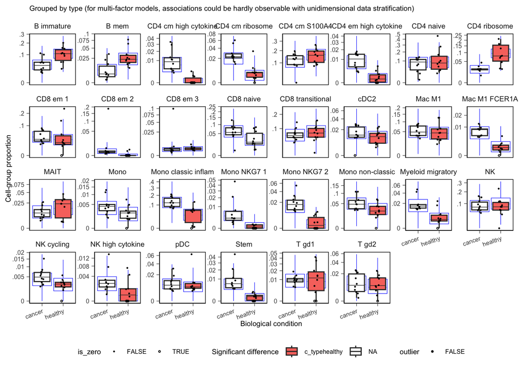

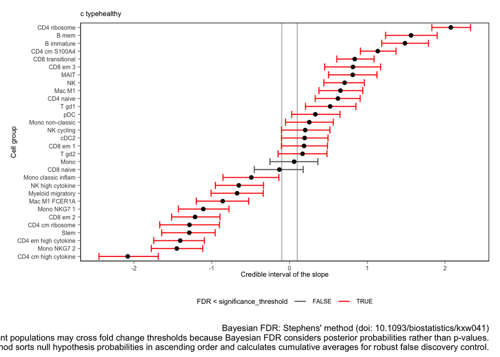

```r
outlier_free_estimate |>
  sccomp_test(contrasts = "typehealthy") |>
  plot()
```

Now plotting the test against the continuous covariate

```
## Running standalone generated quantities after 1 MCMC chain, with 1 thread(s) per chain...
##
## Chain 1 finished in 0.0 seconds.
```

```
## $boxplot
## $boxplot[[1]]
```

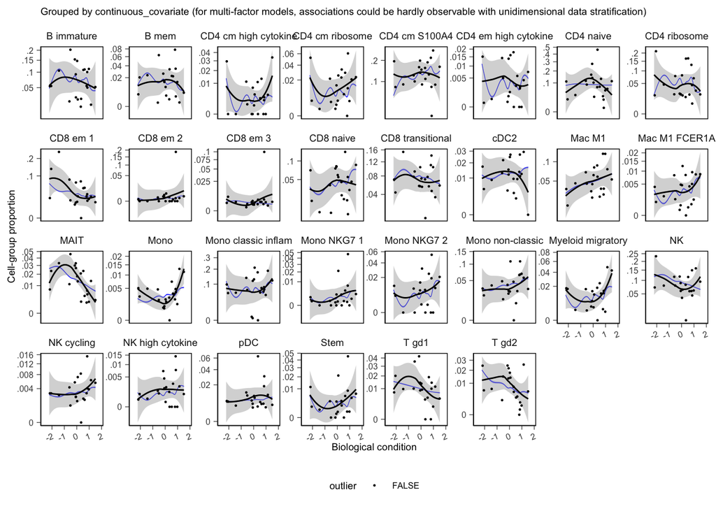

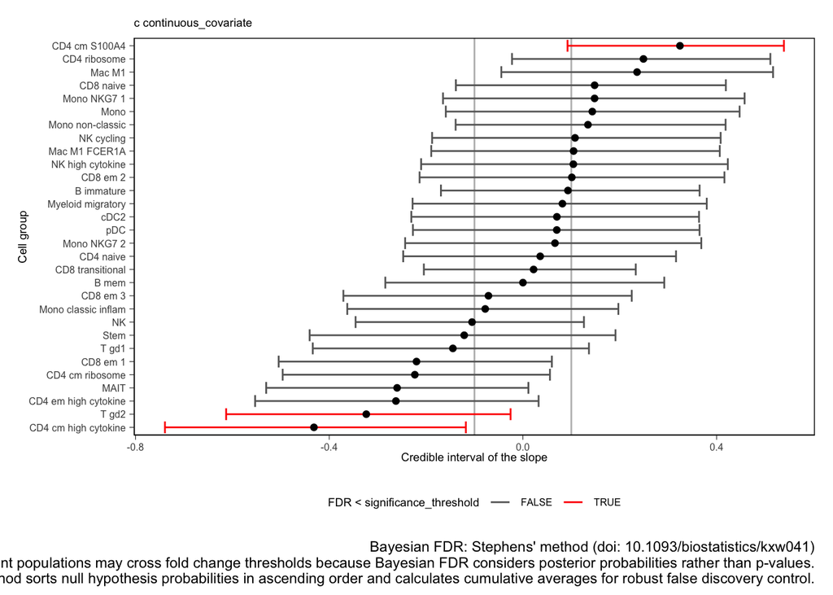

```r
outlier_free_estimate |>
  sccomp_test(contrasts = "continuous_covariate") |>
  plot()
```

[^1]: [Mangiola, Stefano, et al. “sccomp: Robust differential composition and variability analysis for single-cell data.” Proceedings of the National Academy of Sciences 120.33 (2023): e2203828120.](https://doi.org/10.1073/pnas.2203828120)